# Big Bet on Nigeria

Endline Social Network Analysis

Author

Brian Calhoon and Randi Rumbold

# Introduction

The MacArthur Foundation’s Big Bet On Nigeria program supports Nigerian-led efforts to reduce corruption by strengthening accountability, transparency, and participation. A resilient accountability ecosystem—the networks of relationships “between citizens and governing authorities … [and] other important actors, including media, private sector, diverse organized citizen groups, and various actors within the state itself” that collectively support social accountability—is essential to the success and sustainability of On Nigeria’s anticorruption programming (for more on accountability ecosystems, see Halloran’s Accountability Ecosystems: The Evolution of a Keyword). This social network analysis (SNA) report explores how On Nigeria grantees collaborate with other actors in the broader accountability ecosystem and with each other, the outcomes to which collaboration contributes, and how and to what end collaborative networks might be further strengthened, **to bolster anticorruption efforts**, now and in the future.

# Purpose of This Document

This brief analysis of centrality statistics is first meant to inform the selection of cases for the case study portion of the final evaluation, identify corrections in the data, and provide inputs into instrument design for the next phases of the SNA.

Beyond this, it is an initial look at the endline study network. Once more data is collected on the network during an additional survey round, further analysis of the local and global network statistics will reveal additional findings for the final evaluation.

It begins with a short explanation of the centrality statistics used to help understand the organizations in the overall network and their place within it. An interactive visualization of the network follows before a few observations to help inform the case study selection.

*A few notes*

*Please note that this does not currently include the 26 organizations that we expect to add from CMEDIA.*

*The next round of survey data should allow us to eliminate missing data and get locations for all organizations so we can develop a geographic network map. It should also significantly increase the number of connections across the network.*

*Consider the data viz to be first drafts.*

# Methodology

## Endline data

*Please correct this description of events*

In October 2024, EnCompass held a workshop in Abuja, Nigeria with On Nigeria grantees in all four cohorts (Behavior Change, Criminal Justice, Joinbodi, and Media and Journalism). Each grantee identified their primary partners, and in November 2024, EnCompass followed up with each grantee and identified partners to identify additional partner relationships. In January/February 2025, EnCompass will conduct an additional follow up survey and focus group discussions.

To clean, analyze, and visualize the network data, EnCompass used the R programming language and the [igraph](https://igraph.org/) network analysis package.

# The network: First Cut

Networks are used to understand interactions across people, organizations, or things we purchase on the internet. In this case, we are trying to understand the interactions between organizations. In network-speak, we refer to organizations as “nodes” and their connections as “edges”.

# Centrality Statistics

Global centrality statistics help understand each nodes place in the overall network and whether or not they are connected to many or few other nodes in the network.

Four commonly used centrality statistics are Betweenness Centrality, Closeness or Harmonic Centrality, Eigenvector Centrality, and Degree Centrality (overall, out, and in).

**Betweenness centrality** measures the extent to which an organization is connected to other network actors that are not connected to each other. Nodes with high betweenness serve as bridges between different parts of a network.

**Closeness** and **Harmonic Centrality** calculates the average distance between a node and all other nodes in a network. It is used to identify nodes that reach other nodes quickly. In networks with disconnected parts it is used in place of closeness centrality.

**Eigenvector Centrality** is a measure of the influence of a node in a network. Those nodes who are connected to other well-connected nodes will have high eigenvector centrality scores.

**Degree Centrality** is a count of the number of connections of each node. In directed networks it can have both an in-degree and an out-degree score. The out-degree score denotes the number of connections the node initiates, and the in-degree score denotes the number of connections the node receives. The overall degree score is the sum of the in-degree and the out-degree scores.

Additionally, a network’s **density** is a useful statistic to understand, but it is hard to put in context. The calculation is the number of edges divided by the total possible number of edges. A network density of 1 means that all nodes are connected to each other. This is common in small friend group networks, but less common in real-world networks. It would not make sense for a network to be perfectly dense, and optimal density is hard to define. The endline network has a density of 0.0084581.

## Centrality findings

|  | Organization | Betweenness | Harmonic Centrality | Eigen | Degree | Out-degree | In-degree |
| --- | --- | --- | --- | --- | --- | --- | --- |
| 1 | AD 4 Radio | 0 | 0 | 0.14 | 1 | 0 | 1 |
| 2 | AREWA24 | 7 | 1 | 0 | 2 | 1 | 1 |
| 3 | Accountability Lab Nigeria | 351 | 20.18 | 0.41 | 9 | 5 | 4 |
| 4 | Administration of Criminal Justice Monitoring Committee | 1 | 2 | 0.07 | 3 | 2 | 1 |
| 5 | Africa Centre for Development Journalism | 0 | 0 | 0.14 | 1 | 0 | 1 |
| 6 | African Center for Leadership, Strategy and Development | 2 | 1 | 0.02 | 5 | 2 | 3 |
| 7 | African Centre for Media and Information Literacy (AFRIMIL) | 243.45 | 18.18 | 0.56 | 9 | 2 | 7 |
| 8 | African Foundation for Young Media Professionals | 0 | 0 | 0.14 | 1 | 0 | 1 |
| 9 | African Women in Media | 0 | 0 | 0.14 | 1 | 0 | 1 |
| 10 | Agora Policy | 65.17 | 17.18 | 0.09 | 5 | 3 | 2 |

[output cut: 160 more lines]

# Network visualization

Network maps are a great way to see how a network is constructed, and of what it is constructed.

Below is the whole network followed by the network with each of its grantee subgroups highlighted.

*I see acronyms in the baseline report graphics, but I’m not sure where the acronym list is. Insert acronyms for the full names so these graphics make more sense at some point before finalizing.*

**The Whole Network**

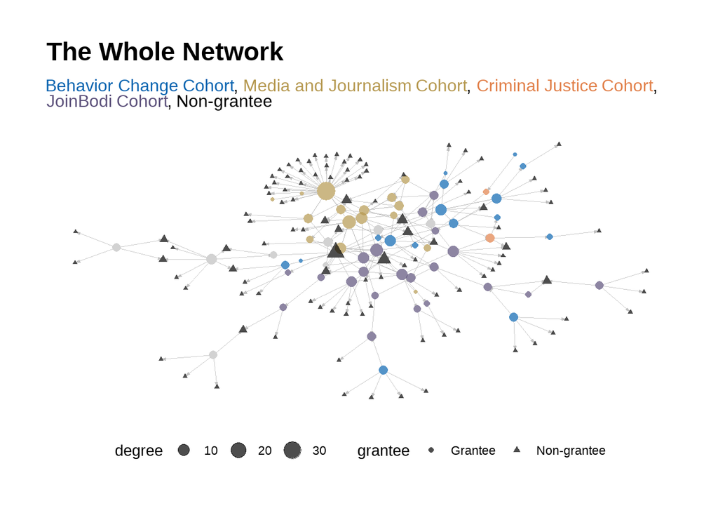

**Behavior Change**

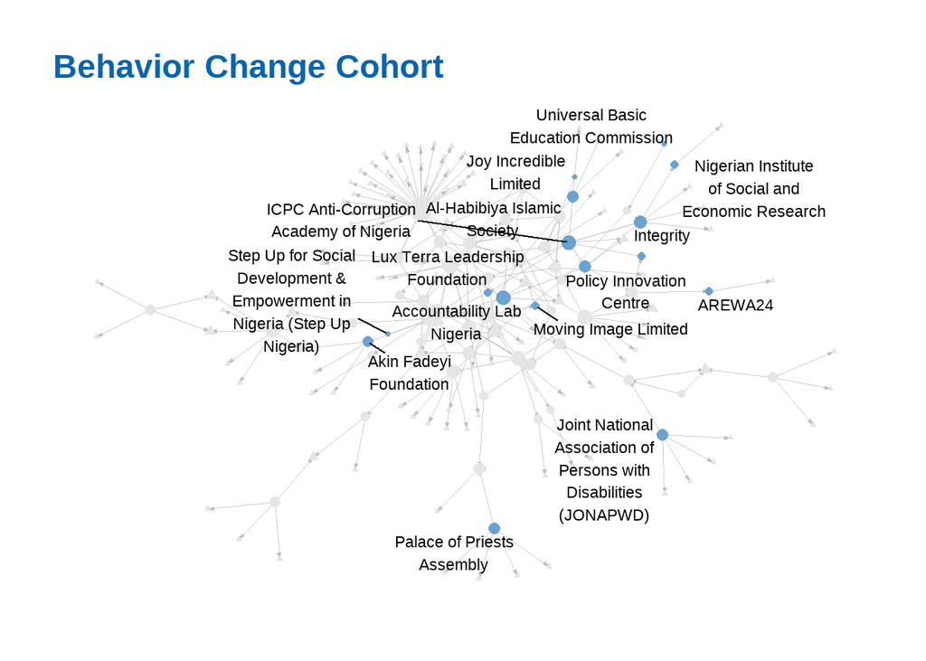

**Media and Journalism**

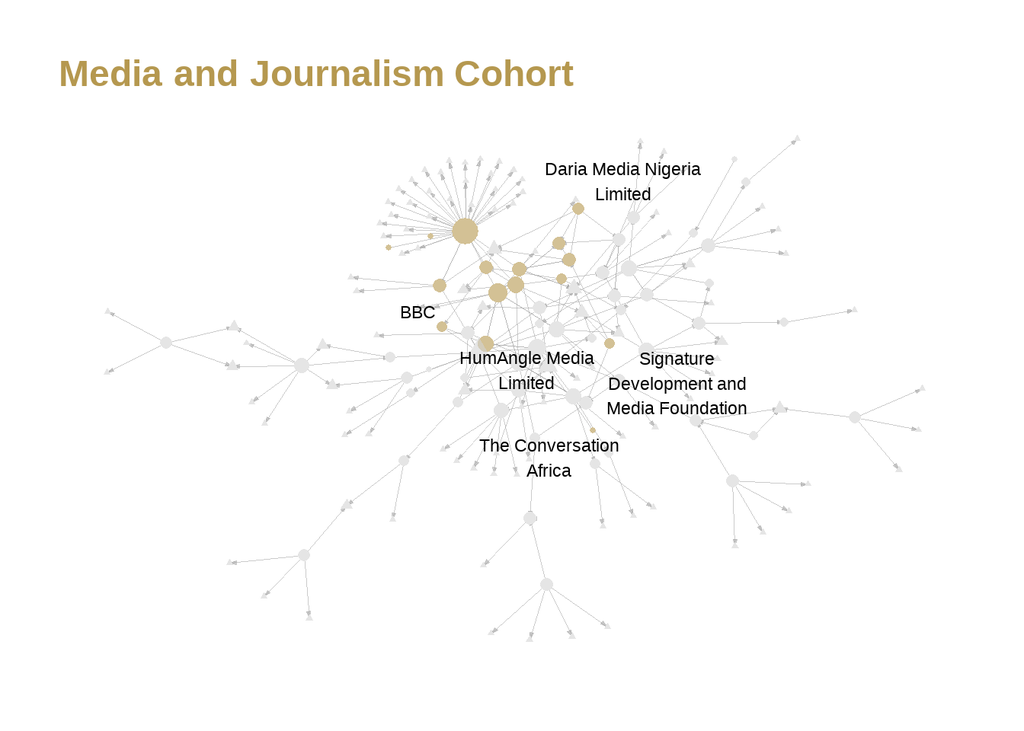

**Criminal Justice**

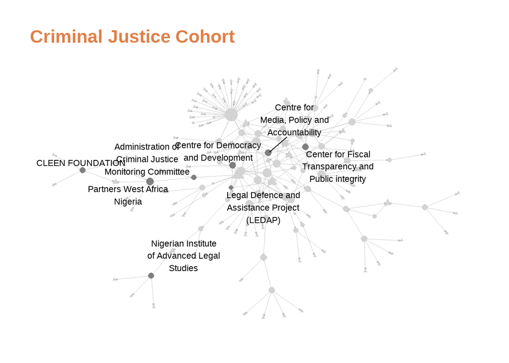

**JoinBodi Subgraph**

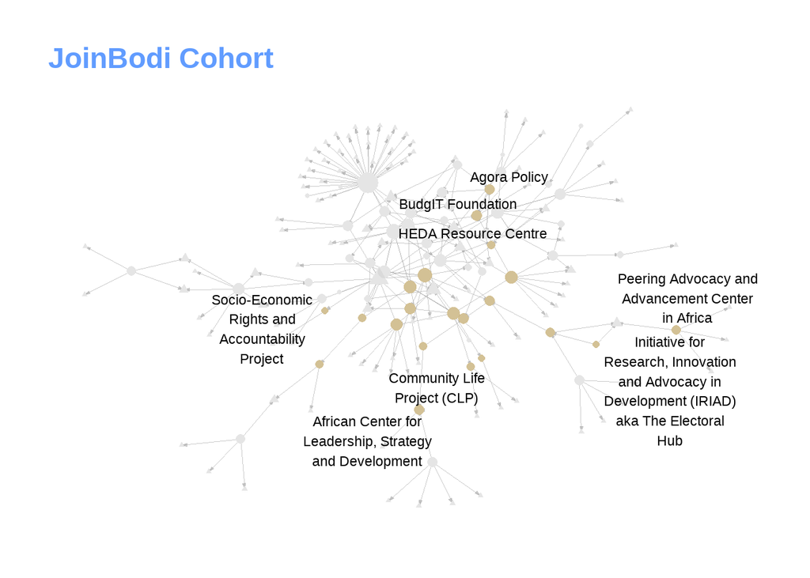

The below graphic allows the reader to explore the network by zooming in and out, clicking on individual nodes, and selecting nodes by their id from a dropdown in the top left.

[interactive chart not shown]

# Observations for Case Study Selection and Further Analysis

## Case Study

### Top 10 Organizations by Centrality Statistic

| Betweenness | Closeness | Degree |
| --- | --- | --- |
| Wole Soyinka Centre for Investigative Journalism (WSCIJ) | ICPC | Wole Soyinka Centre for Investigative Journalism (WSCIJ) |
| Daily Trust Foundation | Centre for Information Technology and Development (CITAD) | ICPC |
| Progressive Impact Organization for Community Development | Accountability Lab Nigeria | Progressive Impact Organization for Community Development |
| ICPC Anti-Corruption Academy of Nigeria | Progressive Impact Organization for Community Development | Centre for Information Technology and Development (CITAD) |
| Accountability Lab Nigeria | Daily Trust Foundation | Daily Trust Foundation |
| Centre for Media, Policy and Accountability | HumAngle Media Limited | Accountability Lab Nigeria |
| African Centre for Media and Information Literacy (AFRIMIL) | African Centre for Media and Information Literacy (AFRIMIL) | African Centre for Media and Information Literacy (AFRIMIL) |
| HumAngle Media Limited | Wole Soyinka Centre for Investigative Journalism (WSCIJ) | Connected Development(CODE) |
| Women's Rights Advancement and Protection Alternative | Centre for Media, Policy and Accountability | HumAngle Media Limited |
| National Institute for Policy and Strategic Studies, Kuru, Nigeria | Bayero University, Kano | ICPC Anti-Corruption Academy of Nigeria |
|  |  | Public and Private Development Centre (PPDC) |

## Further Analysis

In addition to the calculating the statistics on the global network, further analysis will provide simulated, similar networks to compare global statistics. This should help us know if the network statistics calculated here are what we should expect.

Further analysis will also focus on cohort level (local) network statistics and cross-cohort linkages.